# W03 - Working with sf objects

# Assignment 3 - Modifying maps and working with sf objects

The following is my solution to the different tasks set for this assignment. The way of setup throughout the assignment is based on the given script provided by Adela for this course.

# Goals:

1. In the first exercise, you will learn to construct maps with `tmap()` by modifying the provided code. The libraries, data, and initial code is provided below.
2. In the second exercise, you learn to:
- Understand the provided datasets
- Learn how to reproject spatial data
- Limit your data into an area of interest
- Create a new map
3. In the third exercise, you reproject layers to a shared SRS.
4. In the fourth (and optional) exercise, you create a map of Denmark using online data.

#### Required R libraries

We will use the `sf`, `raster`, and `tmap` packages. Additionally, we will use the `spData` and `spDataLarge` packages that provide new datasets. To install the `spDataLarge`, please load it directly from the author’s github repository at https://github.com/Nowosad/spDataLarge. If the line in the chunk below does not work, check the repository for the other options.

```r
library(sf)
library(raster)
library(tmap)
library(spData)

# To install the spDataLarge uncomment the next line

#install.packages("spDataLarge", repos = "https://geocompr.r-universe.dev")
#install.packages("spData")
library(spDataLarge)
```

# Exercise 1 - Make a map

In this exercise you will learn to make a map with `tmap` library, by adding spatial data layers and modifying the arguments that specify their rendering

#### Data sets

We will use two data sets: `nz_elev` and `nz`. They are contained by the libraries The first one is an elevation raster object for the New Zealand area, and the second one is an sf object with polygons representing the 16 regions of New Zealand.

#### Existing code

Here is the code to create a new map of New Zealand (following Robin Lovelace’s example). Your role is to improve this map based on the suggestions below.

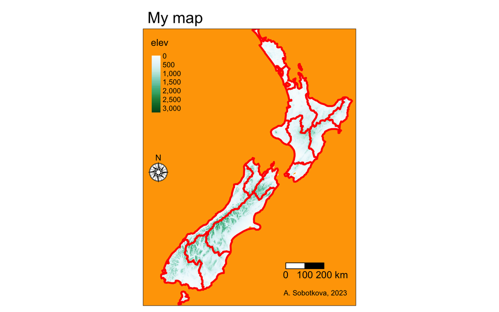

```r
tm_shape(nz_elev)  +
  tm_raster(title = "elev",
            style = "cont",
            palette = "BuGn") +
  tm_shape(nz) +
  tm_borders(col = "red",
             lwd = 3) +
  tm_scale_bar(breaks = c(0, 100, 200),
               text.size = 1) +
  tm_compass(position = c("LEFT", "center"),
             type = "rose",
             size = 2) +
  tm_credits(text = "A. Sobotkova, 2023") +
  tm_layout(main.title = "My map",
            bg.color = "orange",
            inner.margins = c(0, 0, 0, 0))
```

## Tasks

1. Change the map title from “My map” to “New Zealand”.
2. Update the map credits with your own name and today’s date.
3. Change the color palette to “-RdYlGn”. (You can also try other palettes from http://colorbrewer2.org/)
4. Put the north arrow in the top right corner of the map.
5. Improve the legend title by adding the used units (m asl).
6. Increase the number of breaks in the scale bar.
7. Change the borders’ color of the New Zealand’s regions to black. Decrease the line width.
8. Change the background color to any color of your choice.

## Your solution

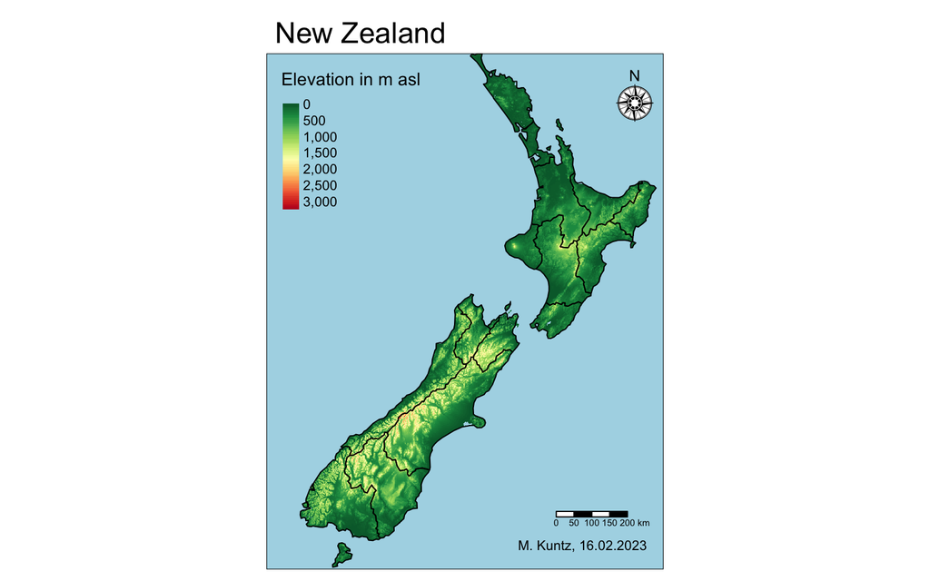

```r
tm_shape(nz_elev)  +
  tm_raster(title = "Elevation in m asl",
            style = "cont",
            palette = "-RdYlGn") +
  tm_shape(nz) +
  tm_borders(col = "black",
             lwd = 1) +
  tm_scale_bar(breaks = c(0, 50, 100, 150, 200),
               text.size = 1) +
  tm_compass(position = c("RIGHT", "top"),
             type = "rose",
             size = 2) +
  tm_credits(text = "M. Kuntz, 16.02.2023") +
  tm_layout(main.title = "New Zealand",
            bg.color = "lightblue",
            inner.margins = c(0, 0, 0, 0))
```

The above map is a result of my chosen improvements done to the original map from the assignment.

# Exercise 2 - Inspect and display spatial data

Read two new datasets, `srtm` and `zion`, using the code below and then follow the instructions and answer the questions related.

#### Preparation: Load data from provided package

You need to have installed the `spDataLarge` package for the following code to work.

```r
srtm  <-  raster(system.file("raster/srtm.tif", package = "spDataLarge"))
zion  <-  read_sf(system.file("vector/zion.gpkg", package = "spDataLarge"))
```

## Instructions and questions

Type answers to the questions as code comments next to or under the code used

- Display the `zion` object and view its structure.
  - What can you say about the content of this file?
  - What type of data does it store?
  - What is the coordinate system used?
  - How many attributes does it contain?
  - What is its geometry?
- Display the `srtm` object and view its structure.
  - What can you say about the content of this file?
  - What type of data does it store?
  - What is the coordinate system used?
  - How many attributes does it contain?
  - How many dimensions does it have?
  - What is the data resolution?